# Risk Factor Analysis

## Outcome Variable

**Outcome Variable:** pers_wast

## Predictor Variables

**Intervention Variable:** impsan

**Adjustment Set:**

unadjusted

## Stratifying Variables

The analysis was stratified on these variable(s):

- agecat
- studyid
- country

## Data Summary

| agecat | studyid | country | impsan | pers_wast | n_cell | n |
| --- | --- | --- | --- | --- | --- | --- |
| 0-24 months | ki0047075b-MAL-ED | BANGLADESH | 1 | 0 | 192 | 242 |
| 0-24 months | ki0047075b-MAL-ED | BANGLADESH | 1 | 1 | 12 | 242 |
| 0-24 months | ki0047075b-MAL-ED | BANGLADESH | 0 | 0 | 37 | 242 |
| 0-24 months | ki0047075b-MAL-ED | BANGLADESH | 0 | 1 | 1 | 242 |
| 0-24 months | ki0047075b-MAL-ED | BRAZIL | 1 | 0 | 204 | 210 |
| 0-24 months | ki0047075b-MAL-ED | BRAZIL | 1 | 1 | 2 | 210 |
| 0-24 months | ki0047075b-MAL-ED | BRAZIL | 0 | 0 | 4 | 210 |
| 0-24 months | ki0047075b-MAL-ED | BRAZIL | 0 | 1 | 0 | 210 |
| 0-24 months | ki0047075b-MAL-ED | INDIA | 1 | 0 | 100 | 233 |
| 0-24 months | ki0047075b-MAL-ED | INDIA | 1 | 1 | 8 | 233 |
| 0-24 months | ki0047075b-MAL-ED | INDIA | 0 | 0 | 113 | 233 |
| 0-24 months | ki0047075b-MAL-ED | INDIA | 0 | 1 | 12 | 233 |
| 0-24 months | ki0047075b-MAL-ED | NEPAL | 1 | 0 | 232 | 236 |
| 0-24 months | ki0047075b-MAL-ED | NEPAL | 1 | 1 | 3 | 236 |
| 0-24 months | ki0047075b-MAL-ED | NEPAL | 0 | 0 | 1 | 236 |
| 0-24 months | ki0047075b-MAL-ED | NEPAL | 0 | 1 | 0 | 236 |
| 0-24 months | ki0047075b-MAL-ED | PERU | 1 | 0 | 65 | 263 |
| 0-24 months | ki0047075b-MAL-ED | PERU | 1 | 1 | 0 | 263 |
| 0-24 months | ki0047075b-MAL-ED | PERU | 0 | 0 | 197 | 263 |
| 0-24 months | ki0047075b-MAL-ED | PERU | 0 | 1 | 1 | 263 |
| 0-24 months | ki0047075b-MAL-ED | SOUTH AFRICA | 1 | 0 | 4 | 250 |
| 0-24 months | ki0047075b-MAL-ED | SOUTH AFRICA | 1 | 1 | 0 | 250 |
| 0-24 months | ki0047075b-MAL-ED | SOUTH AFRICA | 0 | 0 | 244 | 250 |
| 0-24 months | ki0047075b-MAL-ED | SOUTH AFRICA | 0 | 1 | 2 | 250 |
| 0-24 months | ki0047075b-MAL-ED | TANZANIA, UNITED REPUBLIC OF | 1 | 0 | 0 | 241 |
| 0-24 months | ki0047075b-MAL-ED | TANZANIA, UNITED REPUBLIC OF | 1 | 1 | 0 | 241 |
| 0-24 months | ki0047075b-MAL-ED | TANZANIA, UNITED REPUBLIC OF | 0 | 0 | 241 | 241 |
| 0-24 months | ki0047075b-MAL-ED | TANZANIA, UNITED REPUBLIC OF | 0 | 1 | 0 | 241 |
| 0-24 months | ki1017093-NIH-Birth | BANGLADESH | 1 | 0 | 193 | 534 |
| 0-24 months | ki1017093-NIH-Birth | BANGLADESH | 1 | 1 | 14 | 534 |

[output cut: 158 more lines]

The following strata were considered:

- agecat: 0-24 months, studyid: ki0047075b-MAL-ED, country: BANGLADESH
- agecat: 0-24 months, studyid: ki0047075b-MAL-ED, country: BRAZIL
- agecat: 0-24 months, studyid: ki0047075b-MAL-ED, country: INDIA
- agecat: 0-24 months, studyid: ki0047075b-MAL-ED, country: NEPAL
- agecat: 0-24 months, studyid: ki0047075b-MAL-ED, country: PERU
- agecat: 0-24 months, studyid: ki0047075b-MAL-ED, country: SOUTH AFRICA
- agecat: 0-24 months, studyid: ki0047075b-MAL-ED, country: TANZANIA, UNITED REPUBLIC OF
- agecat: 0-24 months, studyid: ki1017093-NIH-Birth, country: BANGLADESH
- agecat: 0-24 months, studyid: ki1017093b-PROVIDE, country: BANGLADESH
- agecat: 0-24 months, studyid: ki1017093c-NIH-Crypto, country: BANGLADESH
- agecat: 0-24 months, studyid: ki1114097-CONTENT, country: PERU
- agecat: 0-24 months, studyid: ki1135781-COHORTS, country: GUATEMALA
- agecat: 0-24 months, studyid: ki1135781-COHORTS, country: INDIA
- agecat: 0-24 months, studyid: ki1135781-COHORTS, country: PHILIPPINES
- agecat: 0-24 months, studyid: ki1148112-LCNI-5, country: MALAWI
- agecat: 0-24 months, studyid: kiGH5241-JiVitA-3, country: BANGLADESH
- agecat: 0-24 months, studyid: kiGH5241-JiVitA-4, country: BANGLADESH
- agecat: 0-6 months, studyid: ki0047075b-MAL-ED, country: BANGLADESH
- agecat: 0-6 months, studyid: ki0047075b-MAL-ED, country: BRAZIL
- agecat: 0-6 months, studyid: ki0047075b-MAL-ED, country: INDIA
- agecat: 0-6 months, studyid: ki0047075b-MAL-ED, country: NEPAL
- agecat: 0-6 months, studyid: ki0047075b-MAL-ED, country: PERU
- agecat: 0-6 months, studyid: ki0047075b-MAL-ED, country: SOUTH AFRICA
- agecat: 0-6 months, studyid: ki0047075b-MAL-ED, country: TANZANIA, UNITED REPUBLIC OF
- agecat: 0-6 months, studyid: ki1017093-NIH-Birth, country: BANGLADESH
- agecat: 0-6 months, studyid: ki1017093b-PROVIDE, country: BANGLADESH
- agecat: 0-6 months, studyid: ki1017093c-NIH-Crypto, country: BANGLADESH
- agecat: 0-6 months, studyid: ki1114097-CONTENT, country: PERU
- agecat: 0-6 months, studyid: ki1135781-COHORTS, country: PHILIPPINES
- agecat: 0-6 months, studyid: kiGH5241-JiVitA-3, country: BANGLADESH
- agecat: 6-24 months, studyid: ki0047075b-MAL-ED, country: BANGLADESH
- agecat: 6-24 months, studyid: ki0047075b-MAL-ED, country: BRAZIL
- agecat: 6-24 months, studyid: ki0047075b-MAL-ED, country: INDIA
- agecat: 6-24 months, studyid: ki0047075b-MAL-ED, country: NEPAL
- agecat: 6-24 months, studyid: ki0047075b-MAL-ED, country: PERU
- agecat: 6-24 months, studyid: ki0047075b-MAL-ED, country: SOUTH AFRICA
- agecat: 6-24 months, studyid: ki0047075b-MAL-ED, country: TANZANIA, UNITED REPUBLIC OF
- agecat: 6-24 months, studyid: ki1017093-NIH-Birth, country: BANGLADESH
- agecat: 6-24 months, studyid: ki1017093b-PROVIDE, country: BANGLADESH
- agecat: 6-24 months, studyid: ki1017093c-NIH-Crypto, country: BANGLADESH
- agecat: 6-24 months, studyid: ki1114097-CONTENT, country: PERU
- agecat: 6-24 months, studyid: ki1135781-COHORTS, country: GUATEMALA
- agecat: 6-24 months, studyid: ki1135781-COHORTS, country: INDIA
- agecat: 6-24 months, studyid: ki1135781-COHORTS, country: PHILIPPINES
- agecat: 6-24 months, studyid: ki1148112-LCNI-5, country: MALAWI
- agecat: 6-24 months, studyid: kiGH5241-JiVitA-3, country: BANGLADESH
- agecat: 6-24 months, studyid: kiGH5241-JiVitA-4, country: BANGLADESH

### Dropped Strata

Some strata were dropped due to rare outcomes:

- agecat: 0-24 months, studyid: ki0047075b-MAL-ED, country: BANGLADESH
- agecat: 0-24 months, studyid: ki0047075b-MAL-ED, country: BRAZIL
- agecat: 0-24 months, studyid: ki0047075b-MAL-ED, country: NEPAL
- agecat: 0-24 months, studyid: ki0047075b-MAL-ED, country: PERU
- agecat: 0-24 months, studyid: ki0047075b-MAL-ED, country: SOUTH AFRICA
- agecat: 0-24 months, studyid: ki0047075b-MAL-ED, country: TANZANIA, UNITED REPUBLIC OF
- agecat: 0-24 months, studyid: ki1017093b-PROVIDE, country: BANGLADESH
- agecat: 0-24 months, studyid: ki1114097-CONTENT, country: PERU
- agecat: 0-24 months, studyid: ki1135781-COHORTS, country: GUATEMALA
- agecat: 0-24 months, studyid: ki1135781-COHORTS, country: PHILIPPINES
- agecat: 0-24 months, studyid: ki1148112-LCNI-5, country: MALAWI
- agecat: 0-6 months, studyid: ki0047075b-MAL-ED, country: BANGLADESH
- agecat: 0-6 months, studyid: ki0047075b-MAL-ED, country: BRAZIL
- agecat: 0-6 months, studyid: ki0047075b-MAL-ED, country: NEPAL
- agecat: 0-6 months, studyid: ki0047075b-MAL-ED, country: PERU
- agecat: 0-6 months, studyid: ki0047075b-MAL-ED, country: SOUTH AFRICA
- agecat: 0-6 months, studyid: ki0047075b-MAL-ED, country: TANZANIA, UNITED REPUBLIC OF
- agecat: 0-6 months, studyid: ki1017093-NIH-Birth, country: BANGLADESH
- agecat: 0-6 months, studyid: ki1017093b-PROVIDE, country: BANGLADESH
- agecat: 0-6 months, studyid: ki1017093c-NIH-Crypto, country: BANGLADESH
- agecat: 0-6 months, studyid: ki1114097-CONTENT, country: PERU
- agecat: 0-6 months, studyid: ki1135781-COHORTS, country: PHILIPPINES
- agecat: 0-6 months, studyid: kiGH5241-JiVitA-3, country: BANGLADESH
- agecat: 6-24 months, studyid: ki0047075b-MAL-ED, country: BANGLADESH
- agecat: 6-24 months, studyid: ki0047075b-MAL-ED, country: BRAZIL
- agecat: 6-24 months, studyid: ki0047075b-MAL-ED, country: NEPAL
- agecat: 6-24 months, studyid: ki0047075b-MAL-ED, country: PERU
- agecat: 6-24 months, studyid: ki0047075b-MAL-ED, country: SOUTH AFRICA
- agecat: 6-24 months, studyid: ki0047075b-MAL-ED, country: TANZANIA, UNITED REPUBLIC OF
- agecat: 6-24 months, studyid: ki1017093b-PROVIDE, country: BANGLADESH
- agecat: 6-24 months, studyid: ki1114097-CONTENT, country: PERU
- agecat: 6-24 months, studyid: ki1135781-COHORTS, country: GUATEMALA
- agecat: 6-24 months, studyid: ki1135781-COHORTS, country: PHILIPPINES
- agecat: 6-24 months, studyid: ki1148112-LCNI-5, country: MALAWI

## Methods Detail

We’re interested in the causal parameters $E[Y_a]$ for all values of $a \in \mathcal{A}$. These parameters represent the mean outcome if, possibly contrary to fact, we intervened to set all units to have $A=a$. Under the randomization and positivity assumptions, these are identified by the statistical parameters $\psi_a=E_W[E_{Y|A,W}(Y|A=a,W)]$. In addition, we’re interested in the mean of $Y$, $E[Y]$ under no intervention (the observed mean). We will estimate these parameters by using SuperLearner to fit the relevant likelihood factors – $E_{Y|A,W}(Y|A=a,W)$ and $p(A=a|W)$, and then updating our likelihood fit using a joint TMLE.

For unadjusted analyses ($W=\{\}$), initial likelihoods were estimated using Lrnr_glm to estimate the simple $E(Y|A)$ and Lrnr_mean to estimate $p(A)$. For adjusted analyses, a small library containing Lrnr_glmnet, Lrnr_xgboost, and Lrnr_mean was used.

Having estimated these parameters, we will then use the delta method to estimate relative risks and attributable risks relative to a prespecified baseline level of $A$.

# Results Detail

## Results Plots

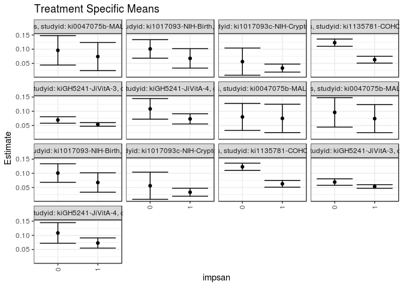

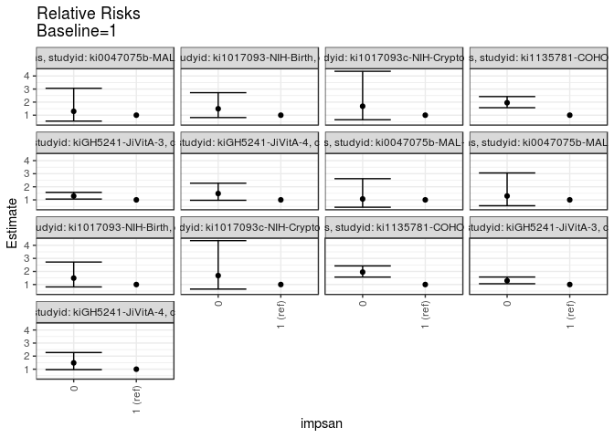

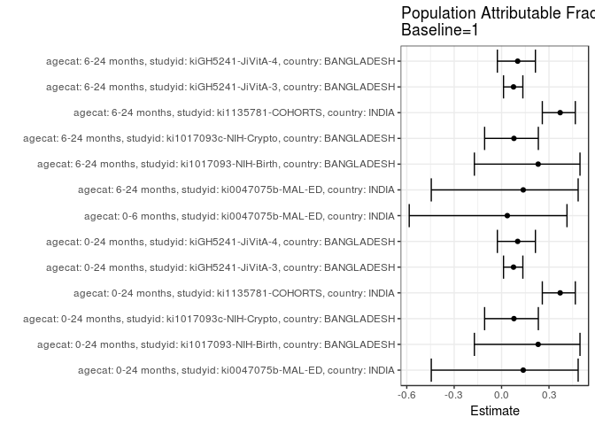

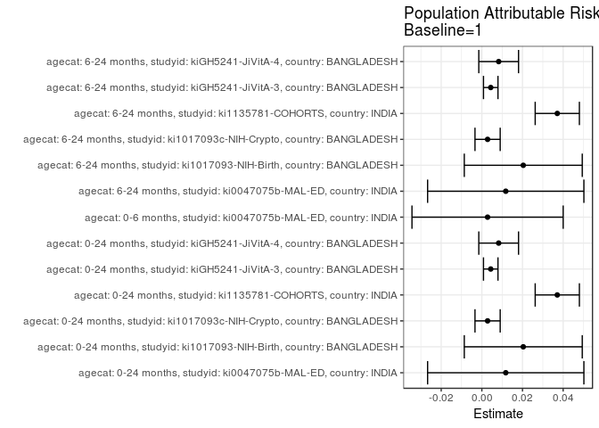

## Results Table

### Parameter: TSM

| agecat | studyid | country | intervention_level | baseline_level | estimate | ci_lower | ci_upper |
| --- | --- | --- | --- | --- | --- | --- | --- |
| 0-24 months | ki0047075b-MAL-ED | INDIA | 1 | NA | 0.0740741 | 0.0245756 | 0.1235725 |
| 0-24 months | ki0047075b-MAL-ED | INDIA | 0 | NA | 0.0960000 | 0.0442456 | 0.1477544 |
| 0-24 months | ki1017093-NIH-Birth | BANGLADESH | 1 | NA | 0.0676329 | 0.0333922 | 0.1018735 |
| 0-24 months | ki1017093-NIH-Birth | BANGLADESH | 0 | NA | 0.1009174 | 0.0682388 | 0.1335961 |
| 0-24 months | ki1017093c-NIH-Crypto | BANGLADESH | 1 | NA | 0.0333333 | 0.0193066 | 0.0473601 |
| 0-24 months | ki1017093c-NIH-Crypto | BANGLADESH | 0 | NA | 0.0561798 | 0.0083069 | 0.1040527 |
| 0-24 months | ki1135781-COHORTS | INDIA | 1 | NA | 0.0629771 | 0.0509672 | 0.0749870 |
| 0-24 months | ki1135781-COHORTS | INDIA | 0 | NA | 0.1229444 | 0.1102077 | 0.1356811 |
| 0-24 months | kiGH5241-JiVitA-3 | BANGLADESH | 1 | NA | 0.0535267 | 0.0470881 | 0.0599652 |
| 0-24 months | kiGH5241-JiVitA-3 | BANGLADESH | 0 | NA | 0.0691563 | 0.0577355 | 0.0805771 |
| 0-24 months | kiGH5241-JiVitA-4 | BANGLADESH | 1 | NA | 0.0730550 | 0.0551101 | 0.0910000 |
| 0-24 months | kiGH5241-JiVitA-4 | BANGLADESH | 0 | NA | 0.1083591 | 0.0720289 | 0.1446894 |
| 0-6 months | ki0047075b-MAL-ED | INDIA | 1 | NA | 0.0747664 | 0.0248235 | 0.1247092 |
| 0-6 months | ki0047075b-MAL-ED | INDIA | 0 | NA | 0.0800000 | 0.0323382 | 0.1276618 |
| 6-24 months | ki0047075b-MAL-ED | INDIA | 1 | NA | 0.0740741 | 0.0245756 | 0.1235725 |
| 6-24 months | ki0047075b-MAL-ED | INDIA | 0 | NA | 0.0960000 | 0.0442456 | 0.1477544 |
| 6-24 months | ki1017093-NIH-Birth | BANGLADESH | 1 | NA | 0.0676329 | 0.0333922 | 0.1018735 |
| 6-24 months | ki1017093-NIH-Birth | BANGLADESH | 0 | NA | 0.1009174 | 0.0682388 | 0.1335961 |
| 6-24 months | ki1017093c-NIH-Crypto | BANGLADESH | 1 | NA | 0.0333333 | 0.0193066 | 0.0473601 |
| 6-24 months | ki1017093c-NIH-Crypto | BANGLADESH | 0 | NA | 0.0561798 | 0.0083069 | 0.1040527 |
| 6-24 months | ki1135781-COHORTS | INDIA | 1 | NA | 0.0629771 | 0.0509672 | 0.0749870 |
| 6-24 months | ki1135781-COHORTS | INDIA | 0 | NA | 0.1229444 | 0.1102077 | 0.1356811 |
| 6-24 months | kiGH5241-JiVitA-3 | BANGLADESH | 1 | NA | 0.0535267 | 0.0470881 | 0.0599652 |
| 6-24 months | kiGH5241-JiVitA-3 | BANGLADESH | 0 | NA | 0.0691563 | 0.0577355 | 0.0805771 |
| 6-24 months | kiGH5241-JiVitA-4 | BANGLADESH | 1 | NA | 0.0730550 | 0.0551101 | 0.0910000 |
| 6-24 months | kiGH5241-JiVitA-4 | BANGLADESH | 0 | NA | 0.1083591 | 0.0720289 | 0.1446894 |

### Parameter: E(Y)

| agecat | studyid | country | intervention_level | baseline_level | estimate | ci_lower | ci_upper |
| --- | --- | --- | --- | --- | --- | --- | --- |
| 0-24 months | ki0047075b-MAL-ED | INDIA | NA | NA | 0.0858369 | 0.0497913 | 0.1218826 |
| 0-24 months | ki1017093-NIH-Birth | BANGLADESH | NA | NA | 0.0880150 | 0.0639627 | 0.1120673 |
| 0-24 months | ki1017093c-NIH-Crypto | BANGLADESH | NA | NA | 0.0361613 | 0.0225058 | 0.0498169 |
| 0-24 months | ki1135781-COHORTS | INDIA | NA | NA | 0.1000969 | 0.0909380 | 0.1092559 |
| 0-24 months | kiGH5241-JiVitA-3 | BANGLADESH | NA | NA | 0.0578981 | 0.0520838 | 0.0637124 |
| 0-24 months | kiGH5241-JiVitA-4 | BANGLADESH | NA | NA | 0.0813362 | 0.0653528 | 0.0973196 |
| 0-6 months | ki0047075b-MAL-ED | INDIA | NA | NA | 0.0775862 | 0.0430879 | 0.1120845 |
| 6-24 months | ki0047075b-MAL-ED | INDIA | NA | NA | 0.0858369 | 0.0497913 | 0.1218826 |
| 6-24 months | ki1017093-NIH-Birth | BANGLADESH | NA | NA | 0.0880150 | 0.0639627 | 0.1120673 |
| 6-24 months | ki1017093c-NIH-Crypto | BANGLADESH | NA | NA | 0.0361613 | 0.0225058 | 0.0498169 |
| 6-24 months | ki1135781-COHORTS | INDIA | NA | NA | 0.1000969 | 0.0909380 | 0.1092559 |
| 6-24 months | kiGH5241-JiVitA-3 | BANGLADESH | NA | NA | 0.0578981 | 0.0520838 | 0.0637124 |
| 6-24 months | kiGH5241-JiVitA-4 | BANGLADESH | NA | NA | 0.0813362 | 0.0653528 | 0.0973196 |

### Parameter: RR

| agecat | studyid | country | intervention_level | baseline_level | estimate | ci_lower | ci_upper |
| --- | --- | --- | --- | --- | --- | --- | --- |
| 0-24 months | ki0047075b-MAL-ED | INDIA | 1 | 1 | 1.000000 | 1.0000000 | 1.000000 |
| 0-24 months | ki0047075b-MAL-ED | INDIA | 0 | 1 | 1.296000 | 0.5491950 | 3.058324 |
| 0-24 months | ki1017093-NIH-Birth | BANGLADESH | 1 | 1 | 1.000000 | 1.0000000 | 1.000000 |
| 0-24 months | ki1017093-NIH-Birth | BANGLADESH | 0 | 1 | 1.492136 | 0.8181052 | 2.721497 |
| 0-24 months | ki1017093c-NIH-Crypto | BANGLADESH | 1 | 1 | 1.000000 | 1.0000000 | 1.000000 |
| 0-24 months | ki1017093c-NIH-Crypto | BANGLADESH | 0 | 1 | 1.685393 | 0.6515657 | 4.359577 |
| 0-24 months | ki1135781-COHORTS | INDIA | 1 | 1 | 1.000000 | 1.0000000 | 1.000000 |
| 0-24 months | ki1135781-COHORTS | INDIA | 0 | 1 | 1.952208 | 1.5713502 | 2.425377 |
| 0-24 months | kiGH5241-JiVitA-3 | BANGLADESH | 1 | 1 | 1.000000 | 1.0000000 | 1.000000 |
| 0-24 months | kiGH5241-JiVitA-3 | BANGLADESH | 0 | 1 | 1.291997 | 1.0603077 | 1.574313 |
| 0-24 months | kiGH5241-JiVitA-4 | BANGLADESH | 1 | 1 | 1.000000 | 1.0000000 | 1.000000 |
| 0-24 months | kiGH5241-JiVitA-4 | BANGLADESH | 0 | 1 | 1.483254 | 0.9671237 | 2.274829 |
| 0-6 months | ki0047075b-MAL-ED | INDIA | 1 | 1 | 1.000000 | 1.0000000 | 1.000000 |
| 0-6 months | ki0047075b-MAL-ED | INDIA | 0 | 1 | 1.070000 | 0.4371800 | 2.618830 |
| 6-24 months | ki0047075b-MAL-ED | INDIA | 1 | 1 | 1.000000 | 1.0000000 | 1.000000 |
| 6-24 months | ki0047075b-MAL-ED | INDIA | 0 | 1 | 1.296000 | 0.5491950 | 3.058324 |
| 6-24 months | ki1017093-NIH-Birth | BANGLADESH | 1 | 1 | 1.000000 | 1.0000000 | 1.000000 |
| 6-24 months | ki1017093-NIH-Birth | BANGLADESH | 0 | 1 | 1.492136 | 0.8181052 | 2.721497 |
| 6-24 months | ki1017093c-NIH-Crypto | BANGLADESH | 1 | 1 | 1.000000 | 1.0000000 | 1.000000 |
| 6-24 months | ki1017093c-NIH-Crypto | BANGLADESH | 0 | 1 | 1.685393 | 0.6515657 | 4.359577 |
| 6-24 months | ki1135781-COHORTS | INDIA | 1 | 1 | 1.000000 | 1.0000000 | 1.000000 |
| 6-24 months | ki1135781-COHORTS | INDIA | 0 | 1 | 1.952208 | 1.5713502 | 2.425377 |
| 6-24 months | kiGH5241-JiVitA-3 | BANGLADESH | 1 | 1 | 1.000000 | 1.0000000 | 1.000000 |
| 6-24 months | kiGH5241-JiVitA-3 | BANGLADESH | 0 | 1 | 1.291997 | 1.0603077 | 1.574313 |
| 6-24 months | kiGH5241-JiVitA-4 | BANGLADESH | 1 | 1 | 1.000000 | 1.0000000 | 1.000000 |
| 6-24 months | kiGH5241-JiVitA-4 | BANGLADESH | 0 | 1 | 1.483254 | 0.9671237 | 2.274829 |

### Parameter: PAR

| agecat | studyid | country | intervention_level | baseline_level | estimate | ci_lower | ci_upper |
| --- | --- | --- | --- | --- | --- | --- | --- |
| 0-24 months | ki0047075b-MAL-ED | INDIA | 1 | NA | 0.0117628 | -0.0266826 | 0.0502083 |
| 0-24 months | ki1017093-NIH-Birth | BANGLADESH | 1 | NA | 0.0203821 | -0.0086347 | 0.0493990 |
| 0-24 months | ki1017093c-NIH-Crypto | BANGLADESH | 1 | NA | 0.0028280 | -0.0033715 | 0.0090275 |
| 0-24 months | ki1135781-COHORTS | INDIA | 1 | NA | 0.0371198 | 0.0262472 | 0.0479925 |
| 0-24 months | kiGH5241-JiVitA-3 | BANGLADESH | 1 | NA | 0.0043715 | 0.0008066 | 0.0079363 |
| 0-24 months | kiGH5241-JiVitA-4 | BANGLADESH | 1 | NA | 0.0082812 | -0.0014975 | 0.0180599 |
| 0-6 months | ki0047075b-MAL-ED | INDIA | 1 | NA | 0.0028199 | -0.0343776 | 0.0400173 |
| 6-24 months | ki0047075b-MAL-ED | INDIA | 1 | NA | 0.0117628 | -0.0266826 | 0.0502083 |
| 6-24 months | ki1017093-NIH-Birth | BANGLADESH | 1 | NA | 0.0203821 | -0.0086347 | 0.0493990 |
| 6-24 months | ki1017093c-NIH-Crypto | BANGLADESH | 1 | NA | 0.0028280 | -0.0033715 | 0.0090275 |
| 6-24 months | ki1135781-COHORTS | INDIA | 1 | NA | 0.0371198 | 0.0262472 | 0.0479925 |
| 6-24 months | kiGH5241-JiVitA-3 | BANGLADESH | 1 | NA | 0.0043715 | 0.0008066 | 0.0079363 |
| 6-24 months | kiGH5241-JiVitA-4 | BANGLADESH | 1 | NA | 0.0082812 | -0.0014975 | 0.0180599 |

### Parameter: PAF

| agecat | studyid | country | intervention_level | baseline_level | estimate | ci_lower | ci_upper |
| --- | --- | --- | --- | --- | --- | --- | --- |
| 0-24 months | ki0047075b-MAL-ED | INDIA | 1 | NA | 0.1370370 | -0.4448822 | 0.4845911 |
| 0-24 months | ki1017093-NIH-Birth | BANGLADESH | 1 | NA | 0.2315757 | -0.1721463 | 0.4962438 |
| 0-24 months | ki1017093c-NIH-Crypto | BANGLADESH | 1 | NA | 0.0782051 | -0.1073443 | 0.2326634 |
| 0-24 months | ki1135781-COHORTS | INDIA | 1 | NA | 0.3708390 | 0.2577927 | 0.4666671 |
| 0-24 months | kiGH5241-JiVitA-3 | BANGLADESH | 1 | NA | 0.0755025 | 0.0123269 | 0.1346372 |
| 0-24 months | kiGH5241-JiVitA-4 | BANGLADESH | 1 | NA | 0.1018145 | -0.0266045 | 0.2141695 |
| 0-6 months | ki0047075b-MAL-ED | INDIA | 1 | NA | 0.0363448 | -0.5844823 | 0.4139212 |
| 6-24 months | ki0047075b-MAL-ED | INDIA | 1 | NA | 0.1370370 | -0.4448822 | 0.4845911 |
| 6-24 months | ki1017093-NIH-Birth | BANGLADESH | 1 | NA | 0.2315757 | -0.1721463 | 0.4962438 |
| 6-24 months | ki1017093c-NIH-Crypto | BANGLADESH | 1 | NA | 0.0782051 | -0.1073443 | 0.2326634 |
| 6-24 months | ki1135781-COHORTS | INDIA | 1 | NA | 0.3708390 | 0.2577927 | 0.4666671 |
| 6-24 months | kiGH5241-JiVitA-3 | BANGLADESH | 1 | NA | 0.0755025 | 0.0123269 | 0.1346372 |
| 6-24 months | kiGH5241-JiVitA-4 | BANGLADESH | 1 | NA | 0.1018145 | -0.0266045 | 0.2141695 |